# Tidyverse - Box Plot of Salaries of Top 6 Majors

## Authors

- **Initial** - Romerl Elizes
- Second - Kevin Benson

## Summary

In this interesting exercise, I used the college-majors 538 datasets [COL] and used the recent-grads.csv for the basis of my initial contribution. Using my previous knowledge of DATA 606 Statistics and usage of tidverse libraries dplyr and ggplot2, I developed a Simple Box Plot displaying the Salary distributions of the top 6 College Majors. Since the mean and the standard deviation was not available in the data set, I had to use good, old-fashioned Statistics to calculate the mean and the standard deviation base on a sample of the data given its size, minimum value, and maximum value for each college major.

## Load Libraries

```r
library(stringr)
library(XML)
library(RCurl)
library(rlist)
library(RJSONIO)
library(tidyr)
library(tidyverse)
library(dplyr)
library(ggplot2)
library(knitr)
library(kableExtra)

options(knitr.table.format = "html")
```

## Define Functions

I defined some functions to help me calculate the mean and the standard deviation of the data. Since we do not know the mean and the standard deviation for row of data, I had to create a rough calculation. Given the size, 25th percentile, and 75th percentile values, I used them to create a random set of numbers using the runif function. Since we do not know the minimum value and the maximum value of the data, I had to use the 25th and 75th percentile values as the them respectively. The biggest caveat in using these functions is that the mean and sd functions will generate random set of numbers. That means that the mean and standard deviation may not be accurate based on the random sample.

```r
calculateMean <- function(Size, minval, maxval) {
    calcvalue <- mean(runif(Size, minval, maxval))
    return(calcvalue)
}

calculateSD <- function(Size, minval, maxval) {
    calcvalue <- sd(runif(Size, minval, maxval))
    return(calcvalue)
}
```

## Work Being Done

For this part of the assignment, I did the following steps:

- I read the raw file of recent-grads.csv and outputed to a table.
- I used kable to display the resulting table.
- I stored the Major, Median Salary, Size, 25th Percentile, and 75th Percentile values in a smaller data frame.
- I sorted the data frame by descending median salary and only used the top 6 salaries for this assignment.
- I added Mean and SD variables and used the mapply function to calculate the mean and standard deviation based on the sample size of each row.
- I used kable to display the resulting table.
- I created a brand new data frame that creates a normalized distribution of 100 points of data based on the calculated mean and standard deviation for each of the top 6 majors by salary.
- I created a box chart that shows a visual representation of the data.

```r
urlfile <- "https://raw.githubusercontent.com/fivethirtyeight/data/master/college-majors/recent-grads.csv"
rgData <- read.table(file = urlfile, header = TRUE, sep = ",")
rgData %>%
  kable() %>%
  kable_styling(bootstrap_options = c("striped", "hover", "condensed", "responsive")) %>%
  scroll_box(width="100%",height="300px")
```

| Rank | Major_code | Major | Total | Men | Women | Major_category | ShareWomen | Sample_size | Employed | Full_time | Part_time | Full_time_year_round | Unemployed | Unemployment_rate | Median | P25th | P75th | College_jobs | Non_college_jobs | Low_wage_jobs |
| --- | --- | --- | --- | --- | --- | --- | --- | --- | --- | --- | --- | --- | --- | --- | --- | --- | --- | --- | --- | --- |
| 1 | 2419 | PETROLEUM ENGINEERING | 2339 | 2057 | 282 | Engineering | 0.1205643 | 36 | 1976 | 1849 | 270 | 1207 | 37 | 0.0183805 | 110000 | 95000 | 125000 | 1534 | 364 | 193 |
| 2 | 2416 | MINING AND MINERAL ENGINEERING | 756 | 679 | 77 | Engineering | 0.1018519 | 7 | 640 | 556 | 170 | 388 | 85 | 0.1172414 | 75000 | 55000 | 90000 | 350 | 257 | 50 |
| 3 | 2415 | METALLURGICAL ENGINEERING | 856 | 725 | 131 | Engineering | 0.1530374 | 3 | 648 | 558 | 133 | 340 | 16 | 0.0240964 | 73000 | 50000 | 105000 | 456 | 176 | 0 |
| 4 | 2417 | NAVAL ARCHITECTURE AND MARINE ENGINEERING | 1258 | 1123 | 135 | Engineering | 0.1073132 | 16 | 758 | 1069 | 150 | 692 | 40 | 0.0501253 | 70000 | 43000 | 80000 | 529 | 102 | 0 |
| 5 | 2405 | CHEMICAL ENGINEERING | 32260 | 21239 | 11021 | Engineering | 0.3416305 | 289 | 25694 | 23170 | 5180 | 16697 | 1672 | 0.0610977 | 65000 | 50000 | 75000 | 18314 | 4440 | 972 |
| 6 | 2418 | NUCLEAR ENGINEERING | 2573 | 2200 | 373 | Engineering | 0.1449670 | 17 | 1857 | 2038 | 264 | 1449 | 400 | 0.1772264 | 65000 | 50000 | 102000 | 1142 | 657 | 244 |
| 7 | 6202 | ACTUARIAL SCIENCE | 3777 | 2110 | 1667 | Business | 0.4413556 | 51 | 2912 | 2924 | 296 | 2482 | 308 | 0.0956522 | 62000 | 53000 | 72000 | 1768 | 314 | 259 |
| 8 | 5001 | ASTRONOMY AND ASTROPHYSICS | 1792 | 832 | 960 | Physical Sciences | 0.5357143 | 10 | 1526 | 1085 | 553 | 827 | 33 | 0.0211674 | 62000 | 31500 | 109000 | 972 | 500 | 220 |
| 9 | 2414 | MECHANICAL ENGINEERING | 91227 | 80320 | 10907 | Engineering | 0.1195589 | 1029 | 76442 | 71298 | 13101 | 54639 | 4650 | 0.0573423 | 60000 | 48000 | 70000 | 52844 | 16384 | 3253 |
| 10 | 2408 | ELECTRICAL ENGINEERING | 81527 | 65511 | 16016 | Engineering | 0.1964503 | 631 | 61928 | 55450 | 12695 | 41413 | 3895 | 0.0591738 | 60000 | 45000 | 72000 | 45829 | 10874 | 3170 |
| 11 | 2407 | COMPUTER ENGINEERING | 41542 | 33258 | 8284 | Engineering | 0.1994126 | 399 | 32506 | 30315 | 5146 | 23621 | 2275 | 0.0654093 | 60000 | 45000 | 75000 | 23694 | 5721 | 980 |
| 12 | 2401 | AEROSPACE ENGINEERING | 15058 | 12953 | 2105 | Engineering | 0.1397928 | 147 | 11391 | 11106 | 2724 | 8790 | 794 | 0.0651621 | 60000 | 42000 | 70000 | 8184 | 2425 | 372 |
| 13 | 2404 | BIOMEDICAL ENGINEERING | 14955 | 8407 | 6548 | Engineering | 0.4378469 | 79 | 10047 | 9017 | 2694 | 5986 | 1019 | 0.0920839 | 60000 | 36000 | 70000 | 6439 | 2471 | 789 |
| 14 | 5008 | MATERIALS SCIENCE | 4279 | 2949 | 1330 | Engineering | 0.3108203 | 22 | 3307 | 2751 | 878 | 1967 | 78 | 0.0230428 | 60000 | 39000 | 65000 | 2626 | 391 | 81 |
| 15 | 2409 | ENGINEERING MECHANICS PHYSICS AND SCIENCE | 4321 | 3526 | 795 | Engineering | 0.1839852 | 30 | 3608 | 2999 | 811 | 2004 | 23 | 0.0063343 | 58000 | 25000 | 74000 | 2439 | 947 | 263 |
| 16 | 2402 | BIOLOGICAL ENGINEERING | 8925 | 6062 | 2863 | Engineering | 0.3207843 | 55 | 6170 | 5455 | 1983 | 3413 | 589 | 0.0871431 | 57100 | 40000 | 76000 | 3603 | 1595 | 524 |
| 17 | 2412 | INDUSTRIAL AND MANUFACTURING ENGINEERING | 18968 | 12453 | 6515 | Engineering | 0.3434732 | 183 | 15604 | 14879 | 2243 | 11326 | 699 | 0.0428755 | 57000 | 37900 | 67000 | 8306 | 3235 | 640 |
| 18 | 2400 | GENERAL ENGINEERING | 61152 | 45683 | 15469 | Engineering | 0.2529598 | 425 | 44931 | 41235 | 7199 | 33540 | 2859 | 0.0598242 | 56000 | 36000 | 69000 | 26898 | 11734 | 3192 |
| 19 | 2403 | ARCHITECTURAL ENGINEERING | 2825 | 1835 | 990 | Engineering | 0.3504425 | 26 | 2575 | 2277 | 343 | 1848 | 170 | 0.0619308 | 54000 | 38000 | 65000 | 1665 | 649 | 137 |
| 20 | 3201 | COURT REPORTING | 1148 | 877 | 271 | Law & Public Policy | 0.2360627 | 14 | 930 | 808 | 223 | 808 | 11 | 0.0116897 | 54000 | 50000 | 54000 | 402 | 528 | 144 |
| 21 | 2102 | COMPUTER SCIENCE | 128319 | 99743 | 28576 | Computers & Mathematics | 0.2226950 | 1196 | 102087 | 91485 | 18726 | 70932 | 6884 | 0.0631728 | 53000 | 39000 | 70000 | 68622 | 25667 | 5144 |
| 22 | 1104 | FOOD SCIENCE | NA | NA | NA | Agriculture & Natural Resources | NA | 36 | 3149 | 2558 | 1121 | 1735 | 338 | 0.0969315 | 53000 | 32000 | 70000 | 1183 | 1274 | 485 |
| 23 | 2502 | ELECTRICAL ENGINEERING TECHNOLOGY | 11565 | 8181 | 3384 | Engineering | 0.2926070 | 97 | 8587 | 7530 | 1873 | 5681 | 824 | 0.0875571 | 52000 | 35000 | 60000 | 5126 | 2686 | 696 |
| 24 | 2413 | MATERIALS ENGINEERING AND MATERIALS SCIENCE | 2993 | 2020 | 973 | Engineering | 0.3250919 | 22 | 2449 | 1658 | 1040 | 1151 | 70 | 0.0277888 | 52000 | 35000 | 62000 | 1911 | 305 | 70 |
| 25 | 6212 | MANAGEMENT INFORMATION SYSTEMS AND STATISTICS | 18713 | 13496 | 5217 | Business | 0.2787901 | 278 | 16413 | 15141 | 2420 | 13017 | 1015 | 0.0582396 | 51000 | 38000 | 60000 | 6342 | 5741 | 708 |
| 26 | 2406 | CIVIL ENGINEERING | 53153 | 41081 | 12072 | Engineering | 0.2271179 | 565 | 43041 | 38302 | 10080 | 29196 | 3270 | 0.0706096 | 50000 | 40000 | 60000 | 28526 | 9356 | 2899 |
| 27 | 5601 | CONSTRUCTION SERVICES | 18498 | 16820 | 1678 | Industrial Arts & Consumer Services | 0.0907125 | 295 | 16318 | 15690 | 1751 | 12313 | 1042 | 0.0600230 | 50000 | 36000 | 60000 | 3275 | 5351 | 703 |
| 28 | 6204 | OPERATIONS LOGISTICS AND E-COMMERCE | 11732 | 7921 | 3811 | Business | 0.3248380 | 156 | 10027 | 9639 | 1183 | 7724 | 504 | 0.0478587 | 50000 | 40000 | 60000 | 1466 | 3629 | 285 |
| 29 | 2499 | MISCELLANEOUS ENGINEERING | 9133 | 7398 | 1735 | Engineering | 0.1899704 | 118 | 7428 | 6811 | 1662 | 5476 | 597 | 0.0743925 | 50000 | 39000 | 65000 | 3445 | 2426 | 365 |
| 30 | 5402 | PUBLIC POLICY | 5978 | 2639 | 3339 | Law & Public Policy | 0.5585480 | 55 | 4547 | 4163 | 1306 | 2776 | 670 | 0.1284263 | 50000 | 35000 | 70000 | 1550 | 1871 | 340 |

[output cut: 143 more lines]

```r
dfChartData <- data.frame(Major = rgData$Major, Median = rgData$Median, Size = rgData$Sample_size, Minval = rgData$P25th, Maxval = rgData$P75th) #, SD = (((rgData$P75th-rgData$P25th)/2)/(0.67*2)))
dfChartData <- dfChartData[order(-dfChartData$Median),]
top6Data <- head(dfChartData, n=6)

top6Data$Mean <- mapply(calculateMean,top6Data$Size, top6Data$Minval, top6Data$Maxval)
top6Data$SD <- mapply(calculateSD,top6Data$Size, top6Data$Minval, top6Data$Maxval)

top6Data %>%
  kable() %>%
  kable_styling(bootstrap_options = c("striped", "hover", "condensed", "responsive")) %>%
  scroll_box(width="100%",height="300px")
```

| Major | Median | Size | Minval | Maxval | Mean | SD |
| --- | --- | --- | --- | --- | --- | --- |
| PETROLEUM ENGINEERING | 110000 | 36 | 95000 | 125000 | 111682.12 | 8787.971 |
| MINING AND MINERAL ENGINEERING | 75000 | 7 | 55000 | 90000 | 76914.52 | 10894.156 |
| METALLURGICAL ENGINEERING | 73000 | 3 | 50000 | 105000 | 59681.45 | 12198.570 |
| NAVAL ARCHITECTURE AND MARINE ENGINEERING | 70000 | 16 | 43000 | 80000 | 62122.11 | 10138.778 |
| CHEMICAL ENGINEERING | 65000 | 289 | 50000 | 75000 | 62833.85 | 7028.370 |
| NUCLEAR ENGINEERING | 65000 | 17 | 50000 | 102000 | 67498.87 | 11800.313 |

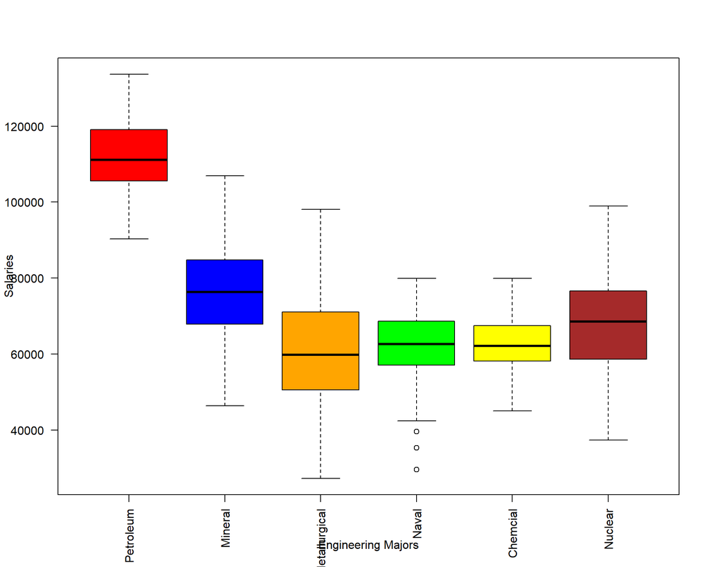

```r
data <- data.frame(
  Petroleum     = rnorm(100,mean=top6Data$Mean[1],sd=top6Data$SD[1]),
  Mineral       = rnorm(100,mean=top6Data$Mean[2],sd=top6Data$SD[2]),
  Metallurgical = rnorm(100,mean=top6Data$Mean[3],sd=top6Data$SD[3]),
  Naval         = rnorm(100,mean=top6Data$Mean[4],sd=top6Data$SD[4]),
  Chemcial      = rnorm(100,mean=top6Data$Mean[5],sd=top6Data$SD[5]),
  Nuclear       = rnorm(100,mean=top6Data$Mean[6],sd=top6Data$SD[6])
)

boxplot(data, ylab = "Salaries", xlab="Engineering Majors",
        las = 2, col = c("red","blue","orange","green","yellow","brown"))
```

## Rooms for Improvement

Certainly there could be room for improvement.

- Is it possible to create a function that uses the same runif function and be able to calculate the mean and standard deviation of the resulting data set? The mean and standard deviation would be more aligned.
- I was hoping to create a dual axis bar and line chart to show salaries on the first Y axis and unemployment on the second Y axis.
- I also investigated the possibility of using a circular bar chart to show the distribution of male and female students by major.

## Additional Work - by Kevin Benson

To extend Romerl’s work, I added a linear regression analysis to see whether there is any relationship between salaries and unemployment rates in the dataset. From economic intuition, we would expect that unemployment rate and salary should be inversely related, i.e., lower unemployment rates should be associated with higher salaries, and vice versa. Let’s see if this is true for the college majors dataset.

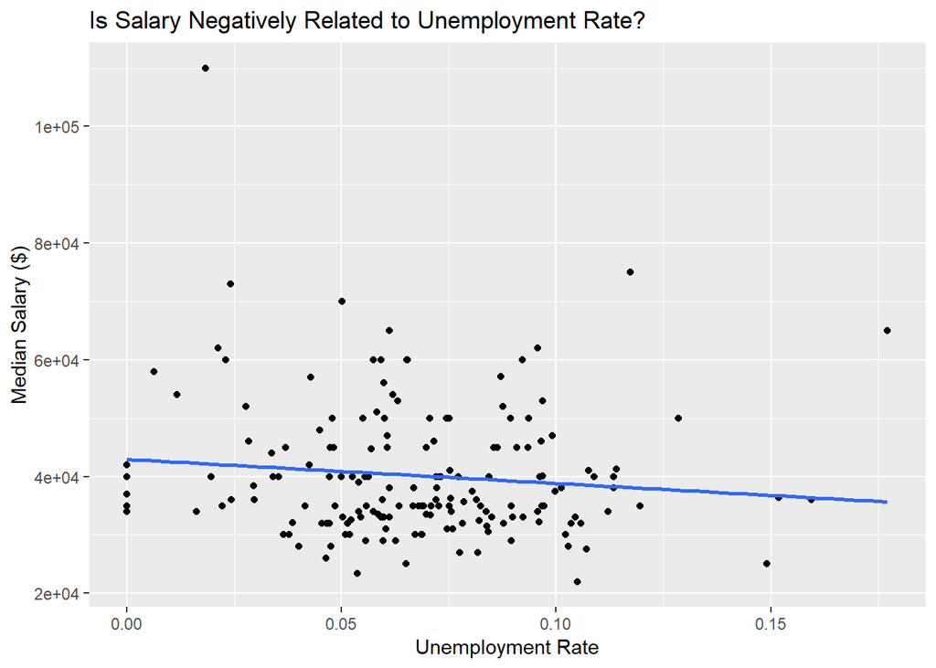

```r
# scatterplot
ggplot(rgData, aes(x = Unemployment_rate, y = Median)) + geom_point() +
    geom_smooth(method = "lm", se = FALSE) +
    labs(title = "Is Salary Negatively Related to Unemployment Rate?",
         x = "Unemployment Rate", y = "Median Salary ($)")
```

```r
# linear model
sal_unemp <- lm(Median ~ Unemployment_rate, data = rgData)
summary(sal_unemp)
```

```
##
## Call:
## lm(formula = Median ~ Unemployment_rate, data = rgData)
##
## Residuals:
##    Min     1Q Median     3Q    Max
## -17351  -7348  -3607   4913  67799
##
## Coefficients:
##                   Estimate Std. Error t value Pr(>|t|)
## (Intercept)          42958       2144  20.032   <2e-16 ***
## Unemployment_rate   -41157      28747  -1.432    0.154
## ---
## Signif. codes:  0 '***' 0.001 '**' 0.01 '*' 0.05 '.' 0.1 ' ' 1
##
## Residual standard error: 11440 on 171 degrees of freedom
## Multiple R-squared:  0.01184,    Adjusted R-squared:  0.006066
## F-statistic:  2.05 on 1 and 171 DF,  p-value: 0.1541
```

It appears that there is a slight negative relationship in the dataset. From the summary of the linear model, we can see that the slope of the regression line (the coefficient estimate for the unemployment rate) is -$41,157. This means that a 1% increase (+0.01) in the unemployment rate is associated with a decline of $412 in median salary, on average. However, this is not a terribly convincing model, since the unemployment coefficient is not statistically significant (high p-value of 15%), and the model $R^2$ is negligible at 1%.

Perhaps the expected relationship is weakened by salaries at the lower end of the income range, where entry-level salaries in lower-paying industries may be semi-static regardless of unemployment rates. In other words, there may be an effective floor on entry-level salaries, which mutes the response to unemployment rate. To see whether that’s the case, let’s redo the regresssion analysis after filtering the dataset for salaries above $40K.

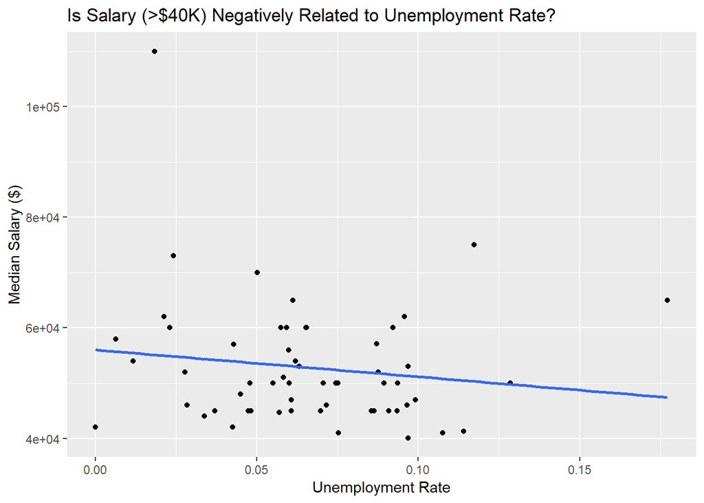

```r
# use only data with salaries > $40K
rgData2 <- rgData %>% filter(Median > 40000)

# scatterplot
ggplot(rgData2, aes(x = Unemployment_rate, y = Median)) + geom_point() + geom_smooth(method = "lm", se = FALSE) +
    labs(title = "Is Salary (>$40K) Negatively Related to Unemployment Rate?", x = "Unemployment Rate", y = "Median Salary ($)")
```

```r
# linear model
sal_unemp2 <- lm(Median ~ Unemployment_rate, data = rgData2)
summary(sal_unemp2)
```

```
##
## Call:
## lm(formula = Median ~ Unemployment_rate, data = rgData2)
##
## Residuals:
##    Min     1Q Median     3Q    Max
## -14020  -6871  -2412   5098  54871
##
## Coefficients:
##                   Estimate Std. Error t value Pr(>|t|)
## (Intercept)          56020       3391  16.521   <2e-16 ***
## Unemployment_rate   -48504      46015  -1.054    0.296
## ---
## Signif. codes:  0 '***' 0.001 '**' 0.01 '*' 0.05 '.' 0.1 ' ' 1
##
## Residual standard error: 11270 on 55 degrees of freedom
## Multiple R-squared:  0.0198, Adjusted R-squared:  0.00198
## F-statistic: 1.111 on 1 and 55 DF,  p-value: 0.2964
```

Unfortunately this didn’t do much for us. The coefficient estimate for the unemployment rate is still not statistically significant (p-value of 30%), and the model $R^2$ is only 2%.

The conclusion from this analysis is that, at first blush, the college majors dataset does not exhibit the expected inverse relationship between salaries and unemployment rates. This may be explained by the fact that recent graduates are typically in entry-level or early career jobs, for which salaries are not very responsive to changing economic conditions like unemployment rates.

## References

**[COL] Recent Grads CSV File from 538 website.** Retrieved from: https://github.com/fivethirtyeight/data/blob/master/college-majors/recent-grads.csv

**[UNI] The Uniform Distribution.** Retrieved from Website: https://www.rdocumentation.org/packages/stats/versions/3.5.1/topics/Uniform

**[VER]** Veronesi, F. **Box-plot with R - Tutorial.** Retrieved from Website: https://www.r-bloggers.com/box-plot-with-r-tutorial/